# Exploratory Data Analysis (EDA) of the *iris* dataset in python

## Magic! in `Jupy Notebook`: Variable Explorer *(kind of)*

Up until now we have created several variables, objects, containers `#younameit` that hold our data, metadata etc  
Aah, **`Spyder`** 's variable explorer **O_o**, where are you..

Eh! There you are!  
http://bit.ly/stack_variable_xplrer_jupy  
or if you don't mind the lack of interactivity, try the following (hint: **`whos`** )

```python
whos
```

[output not shown]

[output cut: 68 more lines]

```
theme                     type             <class 'ggplot.themes.theme.theme'>
theme_538                 type             <class 'ggplot.themes.theme_538.theme_538'>
theme_bw                  type             <class 'ggplot.themes.theme_bw.theme_bw'>
theme_gray                type             <class 'ggplot.themes.theme_gray.theme_gray'>
theme_xkcd                type             <class 'ggplot.themes.theme_xkcd.theme_xkcd'>
themes                    module           <module 'ggplot.themes' f<...>ot\\themes\\__init__.py'>
unicode_literals          _Feature         _Feature((2, 6, 0, 'alpha<...>, 0, 'alpha', 0), 131072)
utils                     module           <module 'ggplot.utils' fr<...>kages\\ggplot\\utils.py'>
virginica                 DataFrame                   sepal length (<...>         1.8  virginica
xlab                      type             <class 'ggplot.chart_components.xlab'>
xlim                      type             <class 'ggplot.chart_components.xlim'>
y                         ndarray          150: 150 elems, type `int32`, 600 bytes
y_labs                    list             n=150
ylab                      type             <class 'ggplot.chart_components.ylab'>
ylim                      type             <class 'ggplot.chart_components.ylim'>
```

# EDA: Exploratory Data Analysis

### i) Numerical EDA

Perfect!  
From **`Bunch`** to a tidy **`DataFrame`**; success!  
We learned a lot about the `pandas.Dataframe` as well.

Now, let's get back to the actual content of our data and get to know them a little better;

- **df.head()**, a glimpse of how the first rows of the DataFrame looks like
- **df.describe()**, some descriptive summary stats
- **df.info()** , a look into our N x m, dimension, #instances etc

#### Let's print the first few rows to check out how the dataframe looks like:

```python
df.head(n=2)
```

|  | sepal length (cm) | sepal width (cm) | petal length (cm) | petal width (cm) | species |
| --- | --- | --- | --- | --- | --- |
| 0 | 5.1 | 3.5 | 1.4 | 0.2 | setosa |
| 1 | 4.9 | 3.0 | 1.4 | 0.2 | setosa |

```python
df["species"].value_counts()
```

```
setosa        50
versicolor    50
virginica     50
Name: species, dtype: int64
```

#### Let's print some info about the dataset, eg:

- Number of instances
- Type of objects
- Memory usage

```python
df.info()
```

```
<class 'pandas.core.frame.DataFrame'>
RangeIndex: 150 entries, 0 to 149
Data columns (total 5 columns):
sepal length (cm)    150 non-null float64
sepal width (cm)     150 non-null float64
petal length (cm)    150 non-null float64
petal width (cm)     150 non-null float64
species              150 non-null object
dtypes: float64(4), object(1)
memory usage: 5.9+ KB
```

```python
df[:][:4]
```

|  | sepal length (cm) | sepal width (cm) | petal length (cm) | petal width (cm) | species |
| --- | --- | --- | --- | --- | --- |
| 0 | 5.1 | 3.5 | 1.4 | 0.2 | setosa |
| 1 | 4.9 | 3.0 | 1.4 | 0.2 | setosa |
| 2 | 4.7 | 3.2 | 1.3 | 0.2 | setosa |
| 3 | 4.6 | 3.1 | 1.5 | 0.2 | setosa |

# None NaNs or NAs!

### Quality control: Checkpoint 0

Check for missing or NaN values in your `DataFrame`.

```python
# Not fully happy with this yet:
df.isnull().head(n=2), df.notnull().head(n=2)
```

```
(   sepal length (cm)  sepal width (cm)  petal length (cm)  petal width (cm)  \
 0              False             False              False             False
 1              False             False              False             False

    species
 0    False
 1    False  ,
    sepal length (cm)  sepal width (cm)  petal length (cm)  petal width (cm)  \
 0               True              True               True              True
 1               True              True               True              True

    species
 0     True
 1     True  )
```

### A better hack to check for null cells:

Found here: https://stackoverflow.com/questions/42921854/how-to-check-if-a-particular-cell-in-pandas-dataframe-isnull

```python
# https://stackoverflow.com/questions/42921854/how-to-check-if-a-particular-cell-in-pandas-dataframe-isnull
df.isnull().any().any(),   # Q: "Is there any empty cell in the DataFrame?"
df.isnull().values.any(),  # Q: "Is there any missing value?"                # FASTEEER! use %timeit and see 4yourself
df.isnull().values.sum(),  # Q: "How many missing valuess are ther?"
df.isnull().sum().sum()    # Q: "Count the total number of empty cells."
```

```
(False,)
```

```
(False,)
```

```
(0,)
```

```
0
```

Cool, no missing values, as expected for **iris** .

## Let's now check out some summary stats about the data:

```python
df.describe()
```

|  | sepal length (cm) | sepal width (cm) | petal length (cm) | petal width (cm) |
| --- | --- | --- | --- | --- |
| count | 150.000000 | 150.000000 | 150.000000 | 150.000000 |
| mean | 5.843333 | 3.054000 | 3.758667 | 1.198667 |
| std | 0.828066 | 0.433594 | 1.764420 | 0.763161 |
| min | 4.300000 | 2.000000 | 1.000000 | 0.100000 |
| 25% | 5.100000 | 2.800000 | 1.600000 | 0.300000 |
| 50% | 5.800000 | 3.000000 | 4.350000 | 1.300000 |
| 75% | 6.400000 | 3.300000 | 5.100000 | 1.800000 |
| max | 7.900000 | 4.400000 | 6.900000 | 2.500000 |

# Visual EDA:

[figure not shown]

Numerical EDA is necessary, but not very intuitive.  
Let's **plot** the data and explore a little more.

We will be using a rather cool #DataViz library, mostly used for statistics related plots, named **"`seaborn`"**.

### Quirky sns syntax found here:

http://bit.ly/sns_quirky_syntax

### Plots for EDA:

http://bit.ly/kaggle_eda_dotpy

# a. Scatter plot

**`sns.FacetGrid`** Documentation: http://bit.ly/sns_FacetGrid

Correlation between two features, here: `sepal length` ~ `sepal width`.

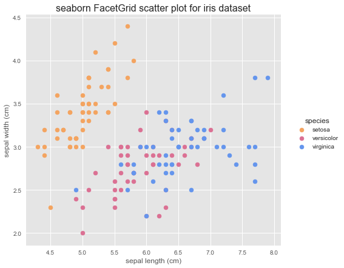

```python
# Quirky sns syntax found here: http://bit.ly/sns_quirky_syntax

# We'll use seaborn's FacetGrid to color the scatterplot by species

# Be prepared - this one's slow.

sns.FacetGrid(data          = df,
              hue           = 'species',
              size          = 6,
              aspect        = 1.15,
              palette       = my_palette,
              legend_out    = True,
              despine       = True,
              margin_titles = True)\

    .map(plt.scatter, "sepal length (cm)", "sepal width (cm)")\
    .add_legend()\
#    .fig.suptitle('Correlation of sepal width to sepal length by species', )
sns.plt.title('seaborn FacetGrid scatter plot for iris dataset', fontsize = 16)
sns.plt.savefig('C:/Users/bruno/Pictures/seaborn_gallery/sns_scatterplot_FacetGrid_iris', dpi = 1200)

plt.show()
```

# b. Boxplots

Seaborn Documentation: http://bit.ly/sns_boxplot

## • `sns.boxplot()`:

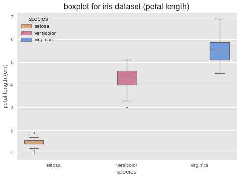

```python
# We can look at an individual feature in Seaborn through a boxplot

sns.boxplot(data        = df,
            x           = 'species',
            y           = 'petal length (cm)',
            hue         = 'species',
            palette     = my_palette,
            saturation  = 0.75,
            width       = 0.8,
            fliersize   = 4,
            linewidth   = 1.2, # how thick the box outline is
            whis        = 1.5, # 1,5 IQR past the low and high quartiles to extend the plot whiskers. Points outside this range will be identified as outliers.
            notch       = False)

sns.plt.title('boxplot for iris dataset (petal length)', fontsize = 16)
sns.plt.savefig('C:/Users/bruno/Pictures/seaborn_gallery/sns_boxplot_iris', dpi = 1200)

sns.plt.show()
```

# • `sns.boxplot()` + `sns.stripplot` hybrid:

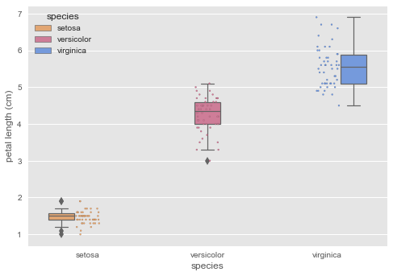

[figure not shown]

```python
# One way we can extend this plot is adding a layer of individual points on top of
# it through Seaborn's striplot
#
# We'll use jitter=True so that all the points don't fall in single vertical lines
# above the species
#
# Saving the resulting axes as ax each time causes the resulting plot to be shown
# on top of the previous axes



ax = sns.boxplot(data        = df,
                 x           = 'species',
                 y           = 'petal length (cm)',
                 hue         = 'species',
                 palette     = my_palette,
                 saturation  = 0.75,
                 width       = .65, # width of boxes or if lazy, margin L and R from boxes
                 fliersize   = 7,   # outlier symbol size | because 7 == o ari8mos tou psefti!
                 linewidth   = 1.2,
                 whis        = 1.5, # 1,5 IQR past the low and high quartiles to extend the plot whiskers. Points outside this range will be identified as outliers.
                 notch       = False)

ax = sns.stripplot(data      = df,
                   x         = 'species',
                   y         = 'petal length (cm)',
                   jitter    = True,
                   linewidth = 0.2,
                   palette   = my_palette,
                   size      = 2,
                   edgecolor = 'gray')

fig = plt.figure()
fig.set_size_inches(11.7, 8.27)
sns.plt.title('seaborn boxplot / stripplot hybrid plot for iris dataset', fontsize = 16)
sns.plt.savefig('C:/Users/bruno/Pictures/seaborn_gallery/sns_boxplot_stripplot_iris', dpi = 1200)

sns.plt.show()
```

# • `sns.boxplot()` + `sns.swarmplot` hybrid:

[figure not shown]

```python
# One way we can extend this plot is adding a layer of individual points on top of
# it through Seaborn's striplot
#
# We'll use jitter=True so that all the points don't fall in single vertical lines
# above the species
#
# Saving the resulting axes as ax each time causes the resulting plot to be shown
# on top of the previous axes



ax = sns.boxplot(data        = df,
                 x           = 'species',
                 y           = 'petal length (cm)',
                 hue         = 'species',
                 palette     = my_palette,
                 saturation  = 0.75,
                 width       = 0.765,
                 fliersize   = 6,
                 linewidth   = 1.2,
                 whis        =  np.inf, # 1,5 IQR past the low and high quartiles to extend the plot whiskers. Points outside this range will be identified as outliers.
                 notch       = False)

ax = sns.swarmplot(data      = df,
                   x         = 'species',
                   y         = 'petal length (cm)',
                   palette   = my_palette,
                   size      = 2.5, split = True)

sns.plt.title('seaborn boxplot/swarmplot for iris dataset (petal length)', fontsize = 16)
sns.plt.savefig('C:/Users/bruno/Pictures/seaborn_gallery/sns_boxplot_swarmplot_iris', dpi = 1200)

sns.plt.show()
```

[figure not shown]

```python
# One way we can extend this plot is by adding a layer of individual points on top of
# it through Seaborn's striplot
#
# We'll use jitter=True so that all the points don't fall in single vertical lines
# above the species
#
# Saving the resulting axes as ax each time causes the resulting plot to be shown
# on top of the previous axes



ax = sns.lvplot(data        = df,
                x           = 'species',
                y           = 'petal length (cm)',
                hue         = 'species',
                palette     = my_palette,
                saturation  = 0.75,
                width       = 0.765,
                k_depth='proportion',
                scale='exponential',
                linewidth=None,
                outlier_prop=None)



ax = sns.swarmplot(data      = df,
                   x         = 'species',
                   y         = 'petal length (cm)',
                   palette   = my_palette,
                   size      = 2.5,
                   split = True)

sns.plt.title('seaborn lvplot/swarmplot for iris dataset (petal length)', fontsize = 16)
sns.plt.savefig('C:/Users/bruno/Pictures/seaborn_gallery/sns_boxplot_swarmplot_iris', dpi = 1200)

sns.plt.show()
```

# c. Violin Plots

A violin plot combines the benefits of the previous two plots and simplifies them  
Denser regions of the data are fatter, and sparser thiner in a violin plot

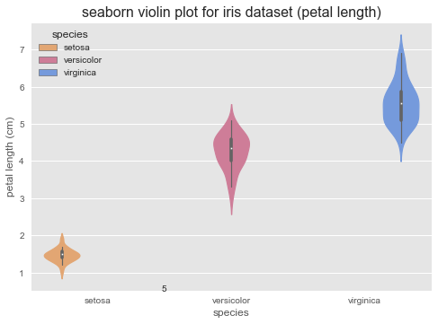

```python
import seaborn as sns

sns.violinplot(data        = df,
               x           = 'species',
               y           = 'petal length (cm)',
               hue         = 'species',
               palette     = my_palette,
               saturation  = 0.75,
               width       = 0.8,
               fliersize   = 6,
               linewidth   = 1.2, # how thick the box outline is
               whis        = 1.5, # 1,5 IQR past the low and high quartiles to extend the plot whiskers. Points outside this range will be identified as outliers.
               notch       = False)


# For exact placing, the title can be added as text:
plt.text(0.5,
         0.5,
         horizontalalignment = 'center',
         fontsize  = 10,
         s = 5 )
         #transform = ax2.transAxes)

sns.plt.title('seaborn violin plot for iris dataset (petal length)', fontsize = 16)
sns.plt.savefig('C:/Users/bruno/Pictures/seaborn_gallery/sns_violin_iris', dpi = 1200)

sns.plt.show()
```

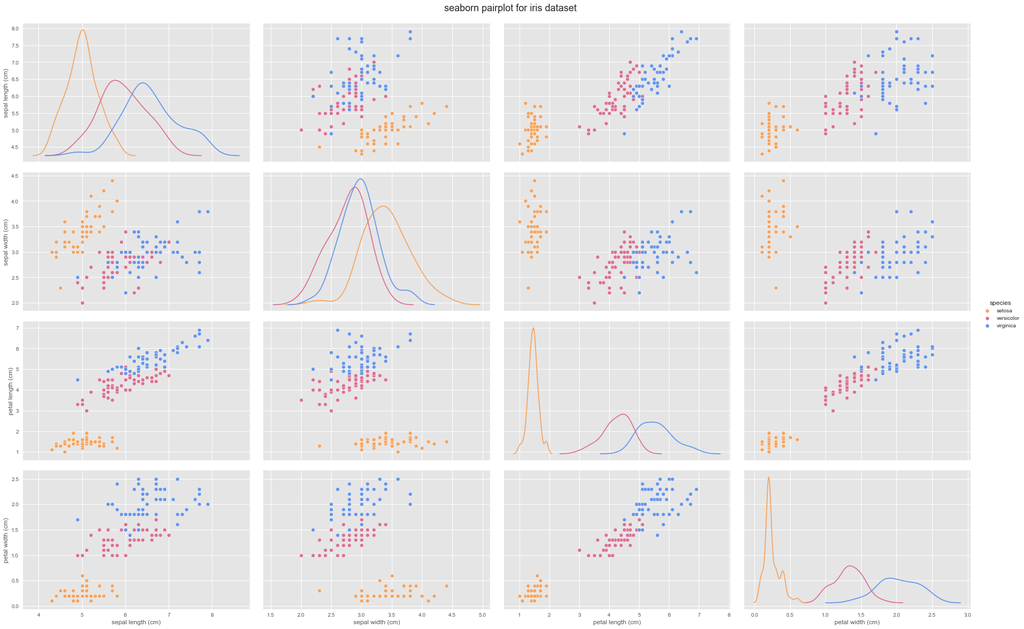

```python
sns.pairplot(data      = df,
             hue       = 'species',
             palette   = my_palette,
             kind      = 'scatter',
             diag_kind = 'kde', # kde
             markers   = None,
             size      = 4,
             aspect    = 1.6 )\
    .fig.suptitle('seaborn pairplot for iris dataset',
                  fontsize = 18,
                  horizontalalignment = 'center',
                  verticalalignment = 'top',
                  y = 1.02)    #adjust title position # https://stackoverflow.com/questions/12750355/python-matplotlib-figure-title-overlaps-axes-label-when-using-twiny


# For exact placing, the title can be added as text:
##plt.text(0.5, 1.08, figure_title,
##        horizontalalignment='center',
##         fontsize=20,
##        transform = ax2.transAxes)
sns.plt.savefig('C:/Users/bruno/Pictures/seaborn_gallery/sns_pairplot_iris', dpi = 1200)
sns.plt.show()
```

# d. Andrews Curves

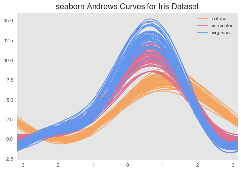

```python
# One cool more sophisticated technique pandas has available is called Andrews Curves
# Andrews Curves involve using attributes of samples as coefficients for Fourier series
# and then plotting these
from pandas.plotting import andrews_curves
andrews_curves(frame        = df,
               class_column = 'species',
               color        = my_palette)

plt.title('seaborn Andrews Curves for Iris Dataset', fontsize = 16)
plt.savefig('C:/Users/bruno/Pictures/seaborn_gallery/andrews_curves_iris', ddpi = 1200)
plt.show()
```

```python
#help(andrews_curves)
```

# EDA, Round 2: `ggplot` in Python?!

```python
#ignore warnings for now
# FOR INSTALLATION INFO: http://bit.ly/ggplot_dotpy
# tl;dr:
# $ pip install ggplot | I like conda better though, so: conda install -c conda-forge ggplot
# BUT do read the manual dude

from ggplot import *
```

```python
help(ggplot)
```

```
Help on class ggplot in module ggplot.ggplot:

class ggplot(builtins.object)
 |  ggplot is the base layer or object that you use to define
 |  the components of your chart (x and y axis, shapes, colors, etc.).
 |  You can combine it with layers (or geoms) to make complex graphics
 |  with minimal effort.
 |  Parameters
 |  -----------
 |  aesthetics :  aes (ggplot.components.aes.aes)
 |      aesthetics of your plot
 |  data :  pandas DataFrame (pd.DataFrame)
 |      a DataFrame with the data you want to plot
 |  Examples
 |  ----------
 |  >>> p = ggplot(aes(x='carat', y='price'), data=diamonds)
 |  >>> print(p + geom_point())
 |  Methods defined here:
 |  __init__(self, aesthetics, data)
 |      Initialize self.  See help(type(self)) for accurate signature.
 |  __repr__(self)
 |      Return repr(self).
 |  add_labels(self)
 |  add_legend(self, legend)
 |  apply_axis_labels(self)
 |  apply_axis_scales(self)
 |  apply_coords(self)
 |  apply_limits(self)
 |  apply_scales(self)
 |  apply_theme(self)
 |  get_facet_groups(self, group)
 |      ???
 |  get_subplot(self, row, col)
 |      Fetches subplot corresponding to row/column
 |  make(self)
 |      Constructs the plot using the methods. This is the 'main' for ggplot
 |  make_facets(self)
 |      Creates figure and axes for m x n facet grid/wrap
 |  save(self, filename, width=None, height=None, dpi=180)
 |      Save ggplot to a .png file.
```

[output cut: 17 more lines]

```
 |          width of the plot in inches
 |      height: int, float
 |          height of the plot in inches
 |  show(self)
 |      Builds and displays your plot.
 |  ----------------------------------------------------------------------
 |  Data descriptors defined here:
 |  __dict__
 |      dictionary for instance variables (if defined)
 |  __weakref__
 |      list of weak references to the object (if defined)
 |  ----------------------------------------------------------------------
 |  Data and other attributes defined here:
 |  CONTINUOUS = ['x', 'y', 'size', 'alpha']
 |  DISCRETE = ['color', 'shape', 'marker', 'alpha', 'linestyle']
```

```python
df.head(n = 2)
```

|  | sepal length (cm) | sepal width (cm) | petal length (cm) | petal width (cm) | species |
| --- | --- | --- | --- | --- | --- |
| 0 | 5.1 | 3.5 | 1.4 | 0.2 | setosa |
| 1 | 4.9 | 3.0 | 1.4 | 0.2 | setosa |